# Ibbotson–Sinquefield scenarios

```julia
# Defaults for running the cells outside Quarto. Under `quarto render` the front-matter
# `params` (overridden by `-P name:value`, see render_reports.sh) are already defined as
# constants, so these assignments are skipped.
@isdefined(spec) || (spec = "ar1935-2025_boot1935-2025_erp4.0")  # directory in specs/
@isdefined(T) || (T = 100)                      # simulated years
@isdefined(horizons) || (horizons = [1, 5, 10, 20, 30, 50, 100])  # horizon table years, ≤ T
@isdefined(n_scen) || (n_scen = 10000)
@isdefined(seed) || (seed = 1234)
```

```julia
import Pkg
Pkg.activate(joinpath(@__DIR__, "..", ".."); io = devnull)

using MacroFinanceScenarios
using MacroFinanceScenarios.IbbotsonSinquefield
using MacroFinanceScenarios.EDA
using MacroFinanceScenarios.ScenariosEvaluation
using CSV, DataFrames, LinearAlgebra, Random, Statistics, StatsBase
using Plots

show_table(t; title = "", digits = 2) =
    display(HTML(sprint(io -> print_table(io, t; backend = :html, digits, title))))

# Everything loaded and computed is in decimal log units; the report shows percent. Means,
# std and percentiles scale by 100; skewness, kurtosis, autocorrelations and correlations
# do not, and `neg` (share of negative values) is already in percent.
pct(sc::Scenarios) = Scenarios(100 .* sc.data, sc.names, sc.start_year)
function pct(df::DataFrame; cols)
    out = copy(df)
    for c in cols
        out[!, c] = 100 .* out[!, c]
    end
    return out
end
moment_cols = [:mean, :std, :min, :p25, :p50, :p75, :max]   # describe_series columns in %
span(p) = "$(p[1])–$(p[2])"
```

## Specification

Specification ar1975-2025_boot1975-2025_erp4.0, estimated in `issm_eda.ipynb` and loaded from its directory in `specs/`; nothing is fitted here.

```julia
spec_dir = joinpath(@__DIR__, "specs", spec)
p = load_issm_params(joinpath(spec_dir, "params.yaml"))
boot_years, U, u_names = load_residuals(joinpath(spec_dir, "bootstrap_residuals.csv"))
u_names == p.names || error("bootstrap residual columns $u_names do not match the state $(p.names)")
hist_moments = CSV.read(joinpath(spec_dir, "hist_moments.csv"), DataFrame; stringtype = String)
hist_cor = CSV.read(joinpath(spec_dir, "hist_correlations.csv"), DataFrame; stringtype = String)
hist_pct = pct(hist_moments; cols = moment_cols)

show_table(DataFrame(parameter = ["AR(1) window", "bootstrap window", "erp_target (%)",
                                  "simulated years", "scenarios", "seed", "last observation"],
                     value = [span(p.ar_period), span(p.boot_period), string(100p.erp_target),
                              string(T), string(n_scen), string(seed), string(p.last_year)]);
           title = "Parameters")
```

| Parameters parameter String | Parameters value String |
| --- | --- |
| AR(1) window | 1975–2025 |
| bootstrap window | 1975–2025 |
| erp_target (%) | 4.0 |
| simulated years | 100 |
| scenarios | 10000 |
| seed | 1234 |
| last observation | 2025 |

Units: returns, rates and moments below are annual log values in percent, except where a table or chart says *simple rate* (`exp(·) − 1` of the log rate, in percent) or *wealth* (of 1 invested); φ, R², skewness, excess kurtosis, autocorrelations and correlations are unit-free.

### AR(1) fits (1975–2025)

```julia
ar_table = DataFrame([(variable = a.variable, n = a.n, c = 100a.c, se_c = 100a.se_c,
                       φ = a.phi, se_φ = a.se_phi, t_φ = a.phi / a.se_phi, σ = 100a.sigma,
                       R² = a.r2, uncond_mean = 100a.c / (1 - a.phi),
                       uncond_std = 100a.sigma / sqrt(1 - a.phi^2))
                      for a in p.model_params if a.variable != "erp"])
show_table(ar_table; title = "AR(1) coefficients, $(span(p.ar_period))")
```

| AR(1) coefficients, 1975–2025 variable String | AR(1) coefficients, 1975–2025 n Int64 | AR(1) coefficients, 1975–2025 c Float64 | AR(1) coefficients, 1975–2025 se_c Float64 | AR(1) coefficients, 1975–2025 φ Float64 | AR(1) coefficients, 1975–2025 se_φ Float64 | AR(1) coefficients, 1975–2025 t_φ Float64 | AR(1) coefficients, 1975–2025 σ Float64 | AR(1) coefficients, 1975–2025 R² Float64 | AR(1) coefficients, 1975–2025 uncond_mean Float64 | AR(1) coefficients, 1975–2025 uncond_std Float64 |
| --- | --- | --- | --- | --- | --- | --- | --- | --- | --- | --- |
| π | 50.0 | 0.91 | 0.43 | 0.73 | 0.1 | 7.51 | 1.74 | 0.54 | 3.31 | 2.53 |
| r | 50.0 | 0.25 | 0.33 | 0.62 | 0.11 | 5.4 | 2.27 | 0.38 | 0.64 | 2.88 |
| tp | 50.0 | 1.99 | 1.16 | -0.1 | 0.14 | -0.7 | 8.0 | 0.01 | 1.81 | 8.04 |

## Simulation

The state `y = [π, r, tp, erp]` follows `y_t = c + A y_{t-1} + u_t` with a diagonal `A` (AR(1) for π, r and tp; erp i.i.d. around `erp_target`). Each simulated year draws one historical year of the demeaned residuals `U` and uses the whole row. Paths start from the last observed year.

```julia
c, A, vnames = p.c, p.A, p.names
sc = simulate_var_bootstrapped_res(c, A, vnames, U, T, n_scen;
                                   y0 = p.y0, start_year = p.start_year, rng = MersenneTwister(seed))
nom = returns_from_components(sc)
rl = returns_from_components(sc; real = true)
μ = unconditional_mean(c, A)

# All simulated series in one Scenarios; rl's :r is sc's :r.
full = Scenarios(vcat(sc.data, nom.data, rl.data[2:3, :, :]),
                 [vnames; nom.names; rl.names[2:3]], sc.start_year)
μπ, μr, μtp, μerp = μ
μ_full = Dict(:π => μπ, :r => μr, :tp => μtp, :erp => μerp,
              :rf => μπ + μr, :rb => μπ + μr + μtp, :re => μπ + μr + μerp,
              :rb_real => μr + μtp, :re_real => μr + μerp)
pick(s::Scenarios, vars) = Scenarios(s.data[indexin(vars, s.names), :, :], vars, s.start_year)

show_table(DataFrame(variable = String.(vnames), c = 100c, φ = diag(A), y0 = 100p.y0,
                     uncond_mean = 100μ);
           title = "VAR(1) intercepts, lags and starting point")
println("Bootstrap residuals: $(size(U, 1)) years, $(first(boot_years))–$(last(boot_years)); ",
        "simulated years $(first(scenario_years(sc)))–$(last(scenario_years(sc))).")
```

```
Bootstrap residuals: 50 years, 1976–2025; simulated years 2026–2125.
```

| VAR(1) intercepts, lags and starting point variable String | VAR(1) intercepts, lags and starting point c Float64 | VAR(1) intercepts, lags and starting point φ Float64 | VAR(1) intercepts, lags and starting point y0 Float64 | VAR(1) intercepts, lags and starting point uncond_mean Float64 |
| --- | --- | --- | --- | --- |
| π | 0.91 | 0.73 | 2.64 | 3.31 |
| r | 0.25 | 0.62 | 1.54 | 0.64 |
| tp | 1.99 | -0.1 | 1.88 | 1.81 |
| erp | 4.0 | 0.0 | 8.71 | 4.0 |

## Fan charts

5–95 and 25–75 percentile bands, median, and the unconditional mean of the VAR (dashed), mapped to each series (e.g. `re`: `μ_π + μ_r + erp_target`; real returns without `μ_π`).

```julia
fans(vars; kwargs...) = [v === nothing ? plot(; framestyle = :none) :
                         fan(full, v; μ = μ_full[v], kwargs...) for v in vars]
```

```
fans (generic function with 1 method)
```

### Cumulative wealth

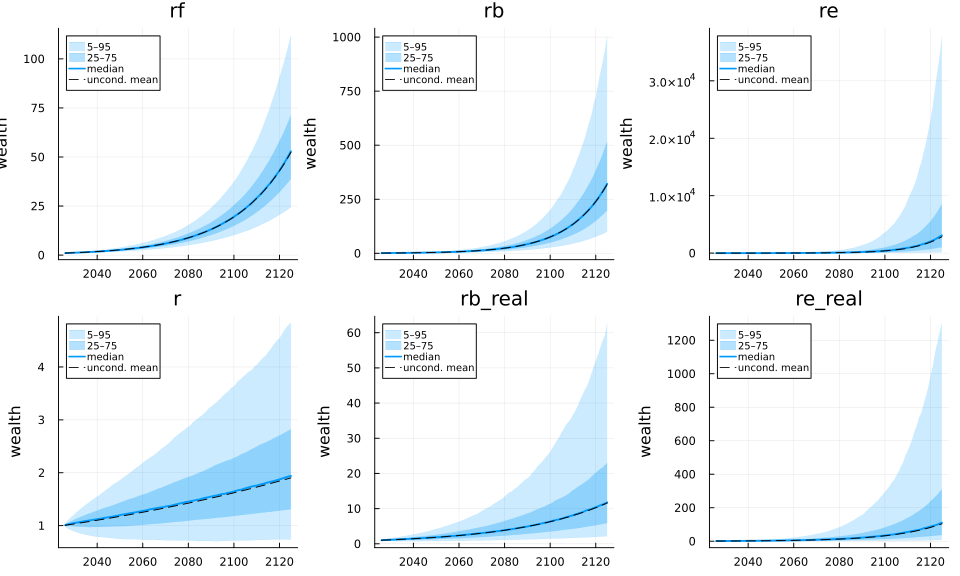

Wealth of 1 invested, nominal (top) and real (bottom)

```julia
plot(fans([:rf, :rb, :re, :r, :rb_real, :re_real]; kind = :wealth)...;
     layout = (2, 3), size = (1000, 600), ylabel = "wealth")
```

### Annualised returns

Geometric-average annual return (annual inflation rate for π) over the first `h` years, `exp(sum(x_1..h)/h) − 1`.

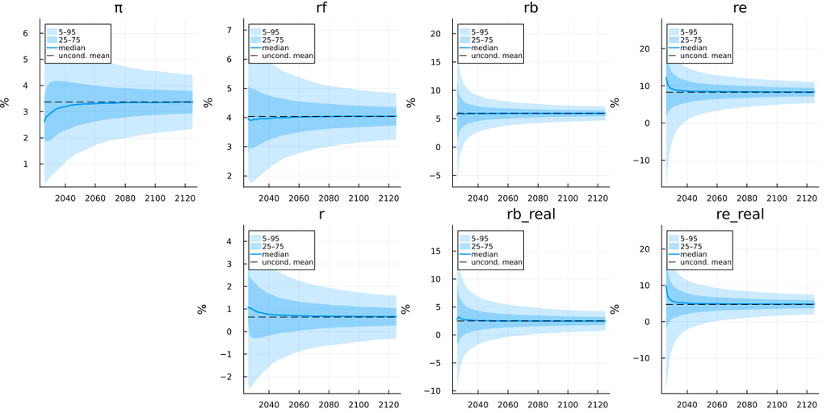

Annualised simple rates: inflation and nominal returns (top), real returns (bottom)

```julia
plot(fans([:π, :rf, :rb, :re, nothing, :r, :rb_real, :re_real]; kind = :annualised,
          simple = true, scale = 100)...;
     layout = (2, 4), size = (1200, 600), ylabel = "%")
```

### Yearly levels

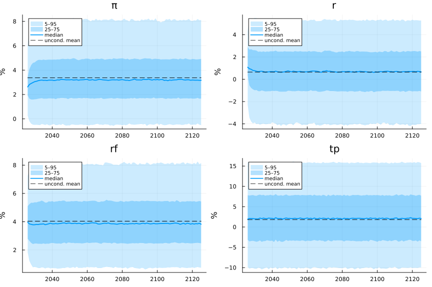

Simulated yearly levels of inflation, the real and nominal short rate and the term premium, simple rates

```julia
plot(fans([:π, :r, :rf, :tp]; kind = :level, simple = true, scale = 100)...;
     layout = (2, 2), size = (900, 600), ylabel = "%")
```

## Evaluation

### Per-path moments

Statistics computed within each simulated path, then summarised across scenarios; the `historical` column is the bootstrap sample (`erp` differs by design: its simulated mean is `erp_target`). `neg` is the percent of years with a negative value.

```julia
for (label, s) in (("components", sc), ("nominal returns", nom), ("real returns", rl))
    for (name, t) in path_moments(pct(s); hist = hist_pct)
        show_table(t; title = "$name ($label)")
    end
end
```

| π (components) statistic String | π (components) historical Float64 | π (components) mean Float64 | π (components) p5 Float64 | π (components) p25 Float64 | π (components) p50 Float64 | π (components) p75 Float64 | π (components) p95 Float64 |
| --- | --- | --- | --- | --- | --- | --- | --- |
| mean | 3.59 | 3.31 | 2.32 | 2.9 | 3.31 | 3.72 | 4.31 |
| std | 2.56 | 2.38 | 1.86 | 2.15 | 2.37 | 2.6 | 2.96 |
| skewness | 1.73 | 0.37 | -0.2 | 0.14 | 0.36 | 0.6 | 0.97 |
| ex_kurtosis | 3.11 | 0.29 | -0.56 | -0.19 | 0.16 | 0.61 | 1.56 |
| ar1 | 0.72 | 0.69 | 0.55 | 0.64 | 0.69 | 0.74 | 0.79 |
| neg | 0.0 | 7.48 | 1.0 | 4.0 | 7.0 | 10.0 | 16.0 |

| r (components) statistic String | r (components) historical Float64 | r (components) mean Float64 | r (components) p5 Float64 | r (components) p25 Float64 | r (components) p50 Float64 | r (components) p75 Float64 | r (components) p95 Float64 |
| --- | --- | --- | --- | --- | --- | --- | --- |
| mean | 0.59 | 0.65 | -0.3 | 0.27 | 0.66 | 1.04 | 1.58 |
| std | 2.82 | 2.75 | 2.24 | 2.53 | 2.74 | 2.96 | 3.31 |
| skewness | -0.19 | -0.16 | -0.74 | -0.4 | -0.16 | 0.07 | 0.42 |
| ex_kurtosis | 0.14 | 0.4 | -0.45 | -0.05 | 0.31 | 0.72 | 1.59 |
| ar1 | 0.61 | 0.58 | 0.44 | 0.53 | 0.59 | 0.64 | 0.7 |
| neg | 39.22 | 39.25 | 25.0 | 33.0 | 39.0 | 45.0 | 54.0 |

| tp (components) statistic String | tp (components) historical Float64 | tp (components) mean Float64 | tp (components) p5 Float64 | tp (components) p25 Float64 | tp (components) p50 Float64 | tp (components) p75 Float64 | tp (components) p95 Float64 |
| --- | --- | --- | --- | --- | --- | --- | --- |
| mean | 1.72 | 1.8 | 0.63 | 1.33 | 1.8 | 2.29 | 2.95 |
| std | 7.91 | 7.86 | 7.03 | 7.53 | 7.86 | 8.2 | 8.69 |
| skewness | -0.12 | -0.18 | -0.44 | -0.28 | -0.18 | -0.07 | 0.09 |
| ex_kurtosis | -0.59 | -0.47 | -0.84 | -0.64 | -0.49 | -0.33 | -0.05 |
| ar1 | -0.1 | -0.1 | -0.26 | -0.17 | -0.11 | -0.04 | 0.06 |
| neg | 39.22 | 38.94 | 31.0 | 36.0 | 39.0 | 42.0 | 46.0 |

| erp (components) statistic String | erp (components) historical Float64 | erp (components) mean Float64 | erp (components) p5 Float64 | erp (components) p25 Float64 | erp (components) p50 Float64 | erp (components) p75 Float64 | erp (components) p95 Float64 |
| --- | --- | --- | --- | --- | --- | --- | --- |
| mean | 6.08 | 4.02 | 1.51 | 3.03 | 4.06 | 5.06 | 6.39 |
| std | 15.17 | 14.85 | 12.16 | 13.69 | 14.82 | 15.97 | 17.67 |
| skewness | -1.51 | -1.42 | -1.94 | -1.67 | -1.46 | -1.21 | -0.73 |
| ex_kurtosis | 3.06 | 2.63 | -0.28 | 1.82 | 2.74 | 3.58 | 4.99 |
| ar1 | -0.02 | -0.01 | -0.16 | -0.08 | -0.01 | 0.05 | 0.16 |
| neg | 23.53 | 31.96 | 24.0 | 29.0 | 32.0 | 35.0 | 40.0 |

| rf (nominal returns) statistic String | rf (nominal returns) historical Float64 | rf (nominal returns) mean Float64 | rf (nominal returns) p5 Float64 | rf (nominal returns) p25 Float64 | rf (nominal returns) p50 Float64 | rf (nominal returns) p75 Float64 | rf (nominal returns) p95 Float64 |
| --- | --- | --- | --- | --- | --- | --- | --- |
| mean | 4.18 | 3.97 | 3.2 | 3.66 | 3.97 | 4.27 | 4.72 |
| std | 3.32 | 2.08 | 1.7 | 1.92 | 2.07 | 2.24 | 2.5 |
| skewness | 0.66 | 0.39 | -0.06 | 0.2 | 0.38 | 0.57 | 0.87 |
| ex_kurtosis | 0.34 | 0.09 | -0.65 | -0.33 | -0.03 | 0.37 | 1.19 |
| ar1 | 0.87 | 0.61 | 0.47 | 0.56 | 0.62 | 0.67 | 0.73 |
| neg | 0.0 | 1.79 | 0.0 | 0.0 | 1.0 | 3.0 | 5.0 |

| rb (nominal returns) statistic String | rb (nominal returns) historical Float64 | rb (nominal returns) mean Float64 | rb (nominal returns) p5 Float64 | rb (nominal returns) p25 Float64 | rb (nominal returns) p50 Float64 | rb (nominal returns) p75 Float64 | rb (nominal returns) p95 Float64 |
| --- | --- | --- | --- | --- | --- | --- | --- |
| mean | 5.9 | 5.77 | 4.6 | 5.29 | 5.77 | 6.25 | 6.92 |
| std | 8.5 | 7.87 | 6.99 | 7.5 | 7.87 | 8.24 | 8.78 |
| skewness | 0.09 | -0.14 | -0.46 | -0.27 | -0.14 | -0.0 | 0.18 |
| ex_kurtosis | 0.22 | -0.21 | -0.71 | -0.45 | -0.24 | -0.0 | 0.39 |
| ar1 | -0.01 | -0.09 | -0.25 | -0.15 | -0.09 | -0.02 | 0.08 |
| neg | 19.61 | 22.41 | 16.0 | 20.0 | 22.0 | 25.0 | 29.0 |

| re (nominal returns) statistic String | re (nominal returns) historical Float64 | re (nominal returns) mean Float64 | re (nominal returns) p5 Float64 | re (nominal returns) p25 Float64 | re (nominal returns) p50 Float64 | re (nominal returns) p75 Float64 | re (nominal returns) p95 Float64 |
| --- | --- | --- | --- | --- | --- | --- | --- |
| mean | 11.61 | 7.98 | 5.27 | 6.95 | 8.04 | 9.06 | 10.55 |
| std | 15.21 | 15.0 | 12.14 | 13.78 | 14.97 | 16.19 | 17.96 |
| skewness | -1.57 | -1.48 | -2.01 | -1.73 | -1.52 | -1.27 | -0.75 |
| ex_kurtosis | 3.48 | 2.97 | -0.1 | 2.12 | 3.08 | 3.98 | 5.49 |
| ar1 | -0.02 | 0.0 | -0.15 | -0.07 | 0.0 | 0.07 | 0.17 |
| neg | 17.65 | 23.68 | 17.0 | 21.0 | 24.0 | 26.0 | 31.0 |

| r (real returns) statistic String | r (real returns) historical Float64 | r (real returns) mean Float64 | r (real returns) p5 Float64 | r (real returns) p25 Float64 | r (real returns) p50 Float64 | r (real returns) p75 Float64 | r (real returns) p95 Float64 |
| --- | --- | --- | --- | --- | --- | --- | --- |
| mean | 0.59 | 0.65 | -0.3 | 0.27 | 0.66 | 1.04 | 1.58 |
| std | 2.82 | 2.75 | 2.24 | 2.53 | 2.74 | 2.96 | 3.31 |
| skewness | -0.19 | -0.16 | -0.74 | -0.4 | -0.16 | 0.07 | 0.42 |
| ex_kurtosis | 0.14 | 0.4 | -0.45 | -0.05 | 0.31 | 0.72 | 1.59 |
| ar1 | 0.61 | 0.58 | 0.44 | 0.53 | 0.59 | 0.64 | 0.7 |
| neg | 39.22 | 39.25 | 25.0 | 33.0 | 39.0 | 45.0 | 54.0 |

| rb_real (real returns) statistic String | rb_real (real returns) historical Float64 | rb_real (real returns) mean Float64 | rb_real (real returns) p5 Float64 | rb_real (real returns) p25 Float64 | rb_real (real returns) p50 Float64 | rb_real (real returns) p75 Float64 | rb_real (real returns) p95 Float64 |
| --- | --- | --- | --- | --- | --- | --- | --- |
| mean | 2.31 | 2.46 | 0.77 | 1.78 | 2.47 | 3.14 | 4.14 |
| std | 9.44 | 8.78 | 7.83 | 8.38 | 8.78 | 9.17 | 9.72 |
| skewness | -0.08 | -0.12 | -0.41 | -0.24 | -0.12 | -0.01 | 0.15 |
| ex_kurtosis | -0.05 | -0.37 | -0.78 | -0.57 | -0.4 | -0.21 | 0.12 |
| ar1 | 0.05 | -0.0 | -0.18 | -0.07 | -0.0 | 0.07 | 0.17 |
| neg | 39.22 | 36.7 | 28.0 | 33.0 | 37.0 | 40.0 | 45.0 |

| re_real (real returns) statistic String | re_real (real returns) historical Float64 | re_real (real returns) mean Float64 | re_real (real returns) p5 Float64 | re_real (real returns) p25 Float64 | re_real (real returns) p50 Float64 | re_real (real returns) p75 Float64 | re_real (real returns) p95 Float64 |
| --- | --- | --- | --- | --- | --- | --- | --- |
| mean | 8.02 | 4.67 | 2.07 | 3.64 | 4.71 | 5.74 | 7.17 |
| std | 15.2 | 14.95 | 12.39 | 13.86 | 14.92 | 16.02 | 17.6 |
| skewness | -1.39 | -1.32 | -1.81 | -1.54 | -1.35 | -1.12 | -0.71 |
| ex_kurtosis | 2.47 | 2.15 | -0.24 | 1.39 | 2.19 | 2.97 | 4.28 |
| ar1 | -0.01 | 0.0 | -0.15 | -0.07 | 0.0 | 0.07 | 0.17 |
| neg | 25.49 | 31.12 | 24.0 | 28.0 | 31.0 | 34.0 | 39.0 |

### Correlations

```julia
for (title, vars) in (("Components and nominal short rate", [:π, :r, :tp, :erp, :rf]),
                      ("Nominal returns, inflation and erp", [:rf, :rb, :re, :π, :erp]),
                      ("Real returns and inflation", [:r, :rb_real, :re_real, :π]))
    s = pick(full, vars)
    show_table(mean_path_correlations(s); title = "$title: mean within-path correlations")
    show_table(path_correlations(s; hist = hist_cor); title = "$title: pairs")
end
```

| Components and nominal short rate: mean within-path correlations variable String | Components and nominal short rate: mean within-path correlations π Float64 | Components and nominal short rate: mean within-path correlations r Float64 | Components and nominal short rate: mean within-path correlations tp Float64 | Components and nominal short rate: mean within-path correlations erp Float64 | Components and nominal short rate: mean within-path correlations rf Float64 |
| --- | --- | --- | --- | --- | --- |
| π | 1.0 | -0.68 | -0.31 | 0.06 | 0.24 |
| r | -0.68 | 1.0 | 0.18 | -0.05 | 0.54 |
| tp | -0.31 | 0.18 | 1.0 | 0.03 | -0.13 |
| erp | 0.06 | -0.05 | 0.03 | 1.0 | 0.0 |
| rf | 0.24 | 0.54 | -0.13 | 0.0 | 1.0 |

| Components and nominal short rate: pairs var1 String | Components and nominal short rate: pairs var2 String | Components and nominal short rate: pairs historical Float64 | Components and nominal short rate: pairs mean Float64 | Components and nominal short rate: pairs p5 Float64 | Components and nominal short rate: pairs p25 Float64 | Components and nominal short rate: pairs p50 Float64 | Components and nominal short rate: pairs p75 Float64 | Components and nominal short rate: pairs p95 Float64 | Components and nominal short rate: pairs hist_rank Float64 |
| --- | --- | --- | --- | --- | --- | --- | --- | --- | --- |
| π | r | -0.24 | -0.68 | -0.8 | -0.74 | -0.69 | -0.62 | -0.52 | 1.0 |
| π | tp | -0.49 | -0.31 | -0.43 | -0.37 | -0.31 | -0.27 | -0.19 | 0.01 |
| π | erp | -0.04 | 0.06 | -0.14 | -0.02 | 0.07 | 0.14 | 0.25 | 0.2 |
| π | rf | 0.57 | 0.24 | -0.04 | 0.13 | 0.25 | 0.36 | 0.5 | 0.98 |
| r | tp | 0.42 | 0.18 | 0.01 | 0.11 | 0.18 | 0.24 | 0.34 | 0.99 |
| r | erp | -0.08 | -0.05 | -0.24 | -0.13 | -0.06 | 0.02 | 0.15 | 0.41 |
| r | rf | 0.66 | 0.54 | 0.31 | 0.46 | 0.55 | 0.63 | 0.73 | 0.83 |
| tp | erp | 0.0 | 0.03 | -0.17 | -0.06 | 0.02 | 0.11 | 0.24 | 0.43 |
| tp | rf | -0.02 | -0.13 | -0.29 | -0.19 | -0.13 | -0.06 | 0.05 | 0.84 |
| erp | rf | -0.1 | 0.0 | -0.2 | -0.08 | 0.0 | 0.08 | 0.19 | 0.2 |

| Nominal returns, inflation and erp: mean within-path correlations variable String | Nominal returns, inflation and erp: mean within-path correlations rf Float64 | Nominal returns, inflation and erp: mean within-path correlations rb Float64 | Nominal returns, inflation and erp: mean within-path correlations re Float64 | Nominal returns, inflation and erp: mean within-path correlations π Float64 | Nominal returns, inflation and erp: mean within-path correlations erp Float64 |
| --- | --- | --- | --- | --- | --- |
| rf | 1.0 | 0.14 | 0.14 | 0.24 | 0.0 |
| rb | 0.14 | 1.0 | 0.05 | -0.25 | 0.03 |
| re | 0.14 | 0.05 | 1.0 | 0.1 | 0.99 |
| π | 0.24 | -0.25 | 0.1 | 1.0 | 0.06 |
| erp | 0.0 | 0.03 | 0.99 | 0.06 | 1.0 |

| Nominal returns, inflation and erp: pairs var1 String | Nominal returns, inflation and erp: pairs var2 String | Nominal returns, inflation and erp: pairs historical Float64 | Nominal returns, inflation and erp: pairs mean Float64 | Nominal returns, inflation and erp: pairs p5 Float64 | Nominal returns, inflation and erp: pairs p25 Float64 | Nominal returns, inflation and erp: pairs p50 Float64 | Nominal returns, inflation and erp: pairs p75 Float64 | Nominal returns, inflation and erp: pairs p95 Float64 | Nominal returns, inflation and erp: pairs hist_rank Float64 |
| --- | --- | --- | --- | --- | --- | --- | --- | --- | --- |
| rf | rb | 0.37 | 0.14 | -0.02 | 0.08 | 0.14 | 0.2 | 0.29 | 0.99 |
| rf | re | 0.12 | 0.14 | -0.05 | 0.07 | 0.14 | 0.22 | 0.31 | 0.41 |
| rf | π | 0.57 | 0.24 | -0.04 | 0.13 | 0.25 | 0.36 | 0.5 | 0.98 |
| rf | erp | -0.1 | 0.0 | -0.2 | -0.08 | 0.0 | 0.08 | 0.19 | 0.2 |
| rb | re | 0.04 | 0.05 | -0.15 | -0.04 | 0.04 | 0.13 | 0.25 | 0.5 |
| rb | π | -0.24 | -0.25 | -0.37 | -0.3 | -0.25 | -0.2 | -0.12 | 0.57 |
| rb | erp | -0.04 | 0.03 | -0.16 | -0.06 | 0.02 | 0.11 | 0.23 | 0.3 |
| re | π | 0.09 | 0.1 | -0.1 | 0.02 | 0.1 | 0.18 | 0.28 | 0.46 |
| re | erp | 0.98 | 0.99 | 0.98 | 0.99 | 0.99 | 0.99 | 0.99 | 0.0 |
| π | erp | -0.04 | 0.06 | -0.14 | -0.02 | 0.07 | 0.14 | 0.25 | 0.2 |

| Real returns and inflation: mean within-path correlations variable String | Real returns and inflation: mean within-path correlations r Float64 | Real returns and inflation: mean within-path correlations rb_real Float64 | Real returns and inflation: mean within-path correlations re_real Float64 | Real returns and inflation: mean within-path correlations π Float64 |
| --- | --- | --- | --- | --- |
| r | 1.0 | 0.47 | 0.13 | -0.68 |
| rb_real | 0.47 | 1.0 | 0.09 | -0.49 |
| re_real | 0.13 | 0.09 | 1.0 | -0.06 |
| π | -0.68 | -0.49 | -0.06 | 1.0 |

| Real returns and inflation: pairs var1 String | Real returns and inflation: pairs var2 String | Real returns and inflation: pairs historical Float64 | Real returns and inflation: pairs mean Float64 | Real returns and inflation: pairs p5 Float64 | Real returns and inflation: pairs p25 Float64 | Real returns and inflation: pairs p50 Float64 | Real returns and inflation: pairs p75 Float64 | Real returns and inflation: pairs p95 Float64 | Real returns and inflation: pairs hist_rank Float64 |
| --- | --- | --- | --- | --- | --- | --- | --- | --- | --- |
| r | rb_real | 0.65 | 0.47 | 0.34 | 0.42 | 0.48 | 0.52 | 0.59 | 0.99 |
| r | re_real | 0.1 | 0.13 | -0.06 | 0.05 | 0.13 | 0.21 | 0.32 | 0.41 |
| r | π | -0.24 | -0.68 | -0.8 | -0.74 | -0.69 | -0.62 | -0.52 | 1.0 |
| rb_real | re_real | 0.1 | 0.09 | -0.11 | 0.0 | 0.09 | 0.18 | 0.31 | 0.52 |
| rb_real | π | -0.48 | -0.49 | -0.6 | -0.54 | -0.5 | -0.45 | -0.38 | 0.58 |
| re_real | π | -0.08 | -0.06 | -0.27 | -0.15 | -0.06 | 0.02 | 0.14 | 0.44 |

### Horizon percentiles

Annualised returns: the geometric-average annual return (annual inflation rate for π) over `h` years, `exp(sum(x_1..h)/h) − 1`, in percent.

```julia
function horizon_tables(vars; kind, label)
    for v in vars
        t = select(horizon_percentiles(full; vars = [v], horizons = filter(<=(T), horizons), kind,
                                       probs = [0.0, 0.05, 0.25, 0.5, 0.75, 0.95, 1.0],
                                       simple = true), Not(:variable))
        t = rename(t, :p0 => :min, :p100 => :max)
        t = pct(t; cols = names(t, Not([:horizon, :year])))
        show_table(t; title = "$v, $label")
    end
end
horizon_tables([:π, :rf, :rb, :re, :r, :rb_real, :re_real]; kind = :annualised,
               label = "annualised (simple rate, %)")
```

| π, annualised (simple rate, %) horizon Int64 | π, annualised (simple rate, %) year Int64 | π, annualised (simple rate, %) mean Float64 | π, annualised (simple rate, %) min Float64 | π, annualised (simple rate, %) p5 Float64 | π, annualised (simple rate, %) p25 Float64 | π, annualised (simple rate, %) p50 Float64 | π, annualised (simple rate, %) p75 Float64 | π, annualised (simple rate, %) p95 Float64 | π, annualised (simple rate, %) max Float64 |
| --- | --- | --- | --- | --- | --- | --- | --- | --- | --- |
| 1.0 | 2026.0 | 2.9 | -0.89 | 0.3 | 1.93 | 2.62 | 3.46 | 6.02 | 8.48 |
| 5.0 | 2030.0 | 3.1 | -2.87 | 0.5 | 1.91 | 2.94 | 4.12 | 6.25 | 13.39 |
| 10.0 | 2035.0 | 3.22 | -2.05 | 0.8 | 2.15 | 3.13 | 4.18 | 5.98 | 10.39 |
| 20.0 | 2045.0 | 3.29 | -0.79 | 1.3 | 2.41 | 3.26 | 4.12 | 5.44 | 9.13 |
| 30.0 | 2055.0 | 3.33 | -0.66 | 1.6 | 2.57 | 3.3 | 4.03 | 5.17 | 8.23 |
| 50.0 | 2075.0 | 3.35 | -0.01 | 1.95 | 2.75 | 3.34 | 3.91 | 4.79 | 7.26 |
| 100.0 | 2125.0 | 3.37 | 1.16 | 2.35 | 2.94 | 3.37 | 3.79 | 4.4 | 5.92 |

| rf, annualised (simple rate, %) horizon Int64 | rf, annualised (simple rate, %) year Int64 | rf, annualised (simple rate, %) mean Float64 | rf, annualised (simple rate, %) min Float64 | rf, annualised (simple rate, %) p5 Float64 | rf, annualised (simple rate, %) p25 Float64 | rf, annualised (simple rate, %) p50 Float64 | rf, annualised (simple rate, %) p75 Float64 | rf, annualised (simple rate, %) p95 Float64 | rf, annualised (simple rate, %) max Float64 |
| --- | --- | --- | --- | --- | --- | --- | --- | --- | --- |
| 1.0 | 2026.0 | 4.11 | 0.92 | 1.88 | 2.81 | 3.96 | 5.1 | 7.23 | 9.39 |
| 5.0 | 2030.0 | 4.03 | -0.42 | 1.82 | 2.97 | 3.93 | 4.98 | 6.58 | 9.64 |
| 10.0 | 2035.0 | 4.03 | -0.16 | 2.08 | 3.11 | 3.98 | 4.85 | 6.23 | 9.92 |
| 20.0 | 2045.0 | 4.03 | 0.5 | 2.45 | 3.33 | 4.0 | 4.69 | 5.74 | 8.34 |
| 30.0 | 2055.0 | 4.04 | 1.11 | 2.7 | 3.45 | 4.01 | 4.59 | 5.49 | 7.43 |
| 50.0 | 2075.0 | 4.05 | 1.73 | 2.97 | 3.59 | 4.03 | 4.48 | 5.14 | 6.86 |
| 100.0 | 2125.0 | 4.05 | 2.24 | 3.25 | 3.73 | 4.05 | 4.36 | 4.83 | 5.99 |

| rb, annualised (simple rate, %) horizon Int64 | rb, annualised (simple rate, %) year Int64 | rb, annualised (simple rate, %) mean Float64 | rb, annualised (simple rate, %) min Float64 | rb, annualised (simple rate, %) p5 Float64 | rb, annualised (simple rate, %) p25 Float64 | rb, annualised (simple rate, %) p50 Float64 | rb, annualised (simple rate, %) p75 Float64 | rb, annualised (simple rate, %) p95 Float64 | rb, annualised (simple rate, %) max Float64 |
| --- | --- | --- | --- | --- | --- | --- | --- | --- | --- |
| 1.0 | 2026.0 | 6.24 | -13.63 | -6.21 | 1.05 | 5.63 | 12.02 | 21.8 | 22.08 |
| 5.0 | 2030.0 | 5.92 | -5.89 | 0.33 | 3.65 | 5.88 | 8.19 | 11.54 | 19.36 |
| 10.0 | 2035.0 | 5.9 | -2.76 | 1.94 | 4.29 | 5.93 | 7.53 | 9.79 | 14.27 |
| 20.0 | 2045.0 | 5.91 | -0.06 | 3.13 | 4.81 | 5.91 | 7.05 | 8.62 | 12.72 |
| 30.0 | 2055.0 | 5.93 | -0.03 | 3.66 | 5.0 | 5.93 | 6.86 | 8.19 | 10.85 |
| 50.0 | 2075.0 | 5.94 | 2.02 | 4.18 | 5.24 | 5.94 | 6.66 | 7.68 | 9.65 |
| 100.0 | 2125.0 | 5.94 | 3.21 | 4.71 | 5.44 | 5.94 | 6.45 | 7.16 | 8.7 |

| re, annualised (simple rate, %) horizon Int64 | re, annualised (simple rate, %) year Int64 | re, annualised (simple rate, %) mean Float64 | re, annualised (simple rate, %) min Float64 | re, annualised (simple rate, %) p5 Float64 | re, annualised (simple rate, %) p25 Float64 | re, annualised (simple rate, %) p50 Float64 | re, annualised (simple rate, %) p75 Float64 | re, annualised (simple rate, %) p95 Float64 | re, annualised (simple rate, %) max Float64 |
| --- | --- | --- | --- | --- | --- | --- | --- | --- | --- |
| 1.0 | 2026.0 | 9.32 | -40.89 | -15.95 | 1.69 | 12.26 | 20.2 | 26.82 | 34.76 |
| 5.0 | 2030.0 | 8.48 | -28.65 | -4.67 | 4.15 | 9.19 | 13.57 | 19.05 | 27.81 |
| 10.0 | 2035.0 | 8.37 | -16.58 | -0.81 | 5.03 | 8.75 | 12.1 | 16.35 | 24.15 |
| 20.0 | 2045.0 | 8.31 | -8.93 | 1.83 | 5.93 | 8.51 | 10.91 | 14.16 | 22.27 |
| 30.0 | 2055.0 | 8.34 | -4.6 | 2.99 | 6.37 | 8.47 | 10.47 | 13.18 | 17.98 |
| 50.0 | 2075.0 | 8.33 | -2.1 | 4.19 | 6.74 | 8.41 | 10.0 | 12.18 | 15.81 |
| 100.0 | 2125.0 | 8.32 | 1.32 | 5.42 | 7.19 | 8.37 | 9.48 | 11.12 | 14.62 |

| r, annualised (simple rate, %) horizon Int64 | r, annualised (simple rate, %) year Int64 | r, annualised (simple rate, %) mean Float64 | r, annualised (simple rate, %) min Float64 | r, annualised (simple rate, %) p5 Float64 | r, annualised (simple rate, %) p25 Float64 | r, annualised (simple rate, %) p50 Float64 | r, annualised (simple rate, %) p75 Float64 | r, annualised (simple rate, %) p95 Float64 | r, annualised (simple rate, %) max Float64 |
| --- | --- | --- | --- | --- | --- | --- | --- | --- | --- |
| 1.0 | 2026.0 | 1.2 | -5.7 | -2.21 | 0.39 | 1.08 | 2.9 | 4.33 | 7.32 |
| 5.0 | 2030.0 | 0.93 | -7.11 | -2.29 | -0.29 | 0.94 | 2.21 | 4.04 | 8.69 |
| 10.0 | 2035.0 | 0.8 | -5.6 | -1.87 | -0.26 | 0.84 | 1.89 | 3.4 | 6.19 |
| 20.0 | 2045.0 | 0.72 | -3.69 | -1.29 | -0.1 | 0.73 | 1.54 | 2.72 | 5.48 |
| 30.0 | 2055.0 | 0.7 | -3.56 | -0.97 | -0.01 | 0.72 | 1.39 | 2.37 | 4.32 |
| 50.0 | 2075.0 | 0.68 | -2.85 | -0.65 | 0.14 | 0.68 | 1.22 | 2.01 | 4.22 |
| 100.0 | 2125.0 | 0.66 | -1.78 | -0.3 | 0.27 | 0.66 | 1.04 | 1.59 | 3.16 |

| rb_real, annualised (simple rate, %) horizon Int64 | rb_real, annualised (simple rate, %) year Int64 | rb_real, annualised (simple rate, %) mean Float64 | rb_real, annualised (simple rate, %) min Float64 | rb_real, annualised (simple rate, %) p5 Float64 | rb_real, annualised (simple rate, %) p25 Float64 | rb_real, annualised (simple rate, %) p50 Float64 | rb_real, annualised (simple rate, %) p75 Float64 | rb_real, annualised (simple rate, %) p95 Float64 | rb_real, annualised (simple rate, %) max Float64 |
| --- | --- | --- | --- | --- | --- | --- | --- | --- | --- |
| 1.0 | 2026.0 | 3.34 | -16.39 | -9.64 | -1.67 | 2.8 | 9.32 | 18.78 | 22.72 |
| 5.0 | 2030.0 | 2.79 | -11.73 | -4.14 | -0.06 | 2.79 | 5.64 | 9.77 | 20.92 |
| 10.0 | 2035.0 | 2.64 | -8.84 | -2.53 | 0.52 | 2.67 | 4.71 | 7.79 | 12.87 |
| 20.0 | 2045.0 | 2.55 | -5.43 | -1.21 | 1.04 | 2.56 | 4.09 | 6.29 | 10.66 |
| 30.0 | 2055.0 | 2.53 | -4.91 | -0.54 | 1.26 | 2.51 | 3.81 | 5.64 | 10.71 |
| 50.0 | 2075.0 | 2.51 | -3.51 | 0.11 | 1.52 | 2.51 | 3.51 | 4.97 | 8.57 |
| 100.0 | 2125.0 | 2.49 | -1.62 | 0.78 | 1.8 | 2.5 | 3.19 | 4.23 | 6.32 |

| re_real, annualised (simple rate, %) horizon Int64 | re_real, annualised (simple rate, %) year Int64 | re_real, annualised (simple rate, %) mean Float64 | re_real, annualised (simple rate, %) min Float64 | re_real, annualised (simple rate, %) p5 Float64 | re_real, annualised (simple rate, %) p25 Float64 | re_real, annualised (simple rate, %) p50 Float64 | re_real, annualised (simple rate, %) p75 Float64 | re_real, annualised (simple rate, %) p95 Float64 | re_real, annualised (simple rate, %) max Float64 |
| --- | --- | --- | --- | --- | --- | --- | --- | --- | --- |
| 1.0 | 2026.0 | 6.25 | -40.36 | -18.48 | -2.04 | 9.74 | 17.03 | 25.26 | 31.42 |
| 5.0 | 2030.0 | 5.23 | -27.55 | -7.26 | 0.84 | 5.71 | 10.21 | 16.06 | 24.58 |
| 10.0 | 2035.0 | 5.0 | -19.31 | -3.64 | 1.64 | 5.24 | 8.6 | 12.89 | 22.38 |
| 20.0 | 2045.0 | 4.87 | -10.69 | -1.23 | 2.51 | 4.97 | 7.35 | 10.6 | 19.21 |
| 30.0 | 2055.0 | 4.86 | -7.03 | -0.1 | 2.87 | 4.92 | 6.9 | 9.63 | 14.5 |
| 50.0 | 2075.0 | 4.82 | -5.14 | 0.93 | 3.29 | 4.86 | 6.42 | 8.53 | 12.53 |
| 100.0 | 2125.0 | 4.79 | -2.31 | 2.09 | 3.7 | 4.82 | 5.9 | 7.44 | 11.03 |

Levels in year `h` (the yearly-level fan chart numbers), simple rates in percent:

```julia
horizon_tables([:π, :rf, :r]; kind = :level, label = "level in year h (simple rate, %)")
```

| π, level in year h (simple rate, %) horizon Int64 | π, level in year h (simple rate, %) year Int64 | π, level in year h (simple rate, %) mean Float64 | π, level in year h (simple rate, %) min Float64 | π, level in year h (simple rate, %) p5 Float64 | π, level in year h (simple rate, %) p25 Float64 | π, level in year h (simple rate, %) p50 Float64 | π, level in year h (simple rate, %) p75 Float64 | π, level in year h (simple rate, %) p95 Float64 | π, level in year h (simple rate, %) max Float64 |
| --- | --- | --- | --- | --- | --- | --- | --- | --- | --- |
| 1.0 | 2026.0 | 2.9 | -0.89 | 0.3 | 1.93 | 2.62 | 3.46 | 6.02 | 8.48 |
| 5.0 | 2030.0 | 3.26 | -4.96 | -0.48 | 1.61 | 3.05 | 4.64 | 7.81 | 15.98 |
| 10.0 | 2035.0 | 3.38 | -4.64 | -0.44 | 1.66 | 3.16 | 4.87 | 7.99 | 16.67 |
| 20.0 | 2045.0 | 3.45 | -4.74 | -0.49 | 1.72 | 3.24 | 4.91 | 8.2 | 17.14 |
| 30.0 | 2055.0 | 3.4 | -5.33 | -0.48 | 1.71 | 3.17 | 4.82 | 8.02 | 16.34 |
| 50.0 | 2075.0 | 3.41 | -4.21 | -0.56 | 1.67 | 3.21 | 4.97 | 8.13 | 16.62 |
| 100.0 | 2125.0 | 3.41 | -4.78 | -0.51 | 1.67 | 3.17 | 4.92 | 8.11 | 15.38 |

| rf, level in year h (simple rate, %) horizon Int64 | rf, level in year h (simple rate, %) year Int64 | rf, level in year h (simple rate, %) mean Float64 | rf, level in year h (simple rate, %) min Float64 | rf, level in year h (simple rate, %) p5 Float64 | rf, level in year h (simple rate, %) p25 Float64 | rf, level in year h (simple rate, %) p50 Float64 | rf, level in year h (simple rate, %) p75 Float64 | rf, level in year h (simple rate, %) p95 Float64 | rf, level in year h (simple rate, %) max Float64 |
| --- | --- | --- | --- | --- | --- | --- | --- | --- | --- |
| 1.0 | 2026.0 | 4.11 | 0.92 | 1.88 | 2.81 | 3.96 | 5.1 | 7.23 | 9.39 |
| 5.0 | 2030.0 | 4.03 | -2.35 | 0.81 | 2.46 | 3.79 | 5.38 | 8.09 | 13.87 |
| 10.0 | 2035.0 | 4.05 | -1.93 | 0.76 | 2.47 | 3.85 | 5.44 | 8.06 | 13.87 |
| 20.0 | 2045.0 | 4.06 | -2.6 | 0.71 | 2.45 | 3.88 | 5.46 | 8.1 | 14.32 |
| 30.0 | 2055.0 | 4.08 | -2.84 | 0.74 | 2.49 | 3.88 | 5.43 | 8.19 | 15.19 |
| 50.0 | 2075.0 | 4.06 | -2.72 | 0.73 | 2.53 | 3.85 | 5.44 | 8.02 | 14.33 |
| 100.0 | 2125.0 | 4.07 | -2.6 | 0.76 | 2.48 | 3.82 | 5.43 | 8.15 | 14.4 |

| r, level in year h (simple rate, %) horizon Int64 | r, level in year h (simple rate, %) year Int64 | r, level in year h (simple rate, %) mean Float64 | r, level in year h (simple rate, %) min Float64 | r, level in year h (simple rate, %) p5 Float64 | r, level in year h (simple rate, %) p25 Float64 | r, level in year h (simple rate, %) p50 Float64 | r, level in year h (simple rate, %) p75 Float64 | r, level in year h (simple rate, %) p95 Float64 | r, level in year h (simple rate, %) max Float64 |
| --- | --- | --- | --- | --- | --- | --- | --- | --- | --- |
| 1.0 | 2026.0 | 1.2 | -5.7 | -2.21 | 0.39 | 1.08 | 2.9 | 4.33 | 7.32 |
| 5.0 | 2030.0 | 0.79 | -11.72 | -3.86 | -0.98 | 0.77 | 2.61 | 5.5 | 12.11 |
| 10.0 | 2035.0 | 0.7 | -12.26 | -3.97 | -1.04 | 0.69 | 2.5 | 5.31 | 11.72 |
| 20.0 | 2045.0 | 0.64 | -11.53 | -4.17 | -1.1 | 0.63 | 2.49 | 5.21 | 11.33 |
| 30.0 | 2055.0 | 0.7 | -10.45 | -3.92 | -1.02 | 0.68 | 2.49 | 5.29 | 12.67 |
| 50.0 | 2075.0 | 0.68 | -11.26 | -4.04 | -1.05 | 0.67 | 2.47 | 5.35 | 12.46 |
| 100.0 | 2125.0 | 0.68 | -11.54 | -4.0 | -1.08 | 0.66 | 2.51 | 5.27 | 12.44 |

### Drawdowns

Maximum drawdown of wealth (in %) and the longest spell below a previous peak (in years), per path over the first `horizon` simulated years (50 by default).

```julia
function dd_table(s; horizon = 50)
    horizon <= size(s.data, 2) || throw(ArgumentError("horizon $horizon exceeds the $(size(s.data, 2)) simulated years"))
    t = drawdown_table(Scenarios(s.data[:, 1:horizon, :], s.names, s.start_year))
    rows = t.statistic .== "max_drawdown"
    num = names(t, Not([:variable, :statistic]))
    t[rows, num] .*= 100
    return t
end
show_table(dd_table(nom); title = "Nominal, first 50 years")
show_table(dd_table(rl); title = "Real, first 50 years")
```

| Nominal, first 50 years variable String | Nominal, first 50 years statistic String | Nominal, first 50 years mean Float64 | Nominal, first 50 years p5 Float64 | Nominal, first 50 years p25 Float64 | Nominal, first 50 years p50 Float64 | Nominal, first 50 years p75 Float64 | Nominal, first 50 years p95 Float64 |
| --- | --- | --- | --- | --- | --- | --- | --- |
| rf | max_drawdown | 0.42 | 0.0 | 0.0 | 0.0 | 0.59 | 1.95 |
| rf | max_dd_length | 0.88 | 0.0 | 0.0 | 0.0 | 1.0 | 4.0 |
| rb | max_drawdown | 14.57 | 7.22 | 10.78 | 14.29 | 17.24 | 24.17 |
| rb | max_dd_length | 4.65 | 2.0 | 3.0 | 4.0 | 6.0 | 9.0 |
| re | max_drawdown | 41.27 | 17.21 | 29.75 | 41.43 | 49.91 | 66.5 |
| re | max_dd_length | 8.34 | 3.0 | 5.0 | 7.0 | 10.0 | 19.0 |

| Real, first 50 years variable String | Real, first 50 years statistic String | Real, first 50 years mean Float64 | Real, first 50 years p5 Float64 | Real, first 50 years p25 Float64 | Real, first 50 years p50 Float64 | Real, first 50 years p75 Float64 | Real, first 50 years p95 Float64 |
| --- | --- | --- | --- | --- | --- | --- | --- |
| r | max_drawdown | 20.5 | 5.32 | 11.66 | 18.36 | 27.27 | 42.98 |
| r | max_dd_length | 22.5 | 6.0 | 12.0 | 20.0 | 31.0 | 47.0 |
| rb_real | max_drawdown | 31.54 | 15.75 | 22.58 | 29.79 | 38.55 | 54.01 |
| rb_real | max_dd_length | 16.1 | 5.0 | 9.0 | 14.0 | 21.0 | 37.0 |
| re_real | max_drawdown | 47.4 | 24.68 | 39.48 | 46.27 | 56.67 | 72.53 |
| re_real | max_dd_length | 13.61 | 4.0 | 8.0 | 11.0 | 17.0 | 31.0 |